# Salvador SARS-CoV-2 Seroprevalence

Mariam Fofana

16 August, 2022

## Aim

This analysis describes the seroprevalence of SARS-CoV-2 and associated risk factors in a cohort of residents in Pau da Lima, an urban slum of Salvador, Brazil. The provided code reproduces the analyses featured in Fofana et al, using a synthetic dataset.

## Sociodemographic characteristics

- Number of individuals with values for the following variables:

– Age: 2039

– Gender: 2039

– Daily per capita income: 2039

– Ethnicity: 1149

– Marital status: 1840

– Employment: 1149

– Employment and per capita income: 2039 & 890

- The sample includes 590 children and 1449 adults.
- Median and IQR for household size: 2 [1 - 3]
- Median and IQR for daily per capita income: 3.3437065 [1.7061999 - 6.105896]
- Median and IQR for age: 29 [16 - 44]
- The total sample includes 2039 individuals with serology results, among 950 households.
- Serological data were available for all members of 0 households, with 0 individuals.
- Adults with 6 or fewer years of education: 505 (35.4385965%)
- Unemployed adults: 567 (56.305859%)

#### Table of demographic characteristics

##### All participants

| Variable | N | Category | Total | IgG+ | IgG- | % IgG+ | LB | UB |
| --- | --- | --- | --- | --- | --- | --- | --- | --- |
| Age | 2039 | <18 | 590 | 305 | 285 | 51.69 | 47.58 | 55.79 |
|  |  | >=60 | 168 | 78 | 90 | 46.43 | 38.76 | 54.26 |
|  |  | 18-29 | 436 | 244 | 192 | 55.96 | 51.16 | 60.66 |
|  |  | 30-44 | 514 | 238 | 276 | 46.30 | 41.94 | 50.72 |
|  |  | 45-59 | 331 | 144 | 187 | 43.50 | 38.12 | 49.04 |
| Gender | 2039 | Female | 1226 | 634 | 592 | 51.71 | 48.87 | 54.54 |
|  |  | Male | 813 | 375 | 438 | 46.13 | 42.66 | 49.62 |
| Race | 1149 | Black | 626 | 305 | 321 | 48.72 | 44.75 | 52.71 |
|  |  | Brown | 462 | 225 | 237 | 48.70 | 44.07 | 53.36 |
|  |  | Other | 14 | 5 | 9 | 35.71 | 13.98 | 64.37 |
|  |  | White | 47 | 21 | 26 | 44.68 | 30.46 | 59.76 |
| Daily per capita income | 2039 | >=5 | 424 | 207 | 217 | 48.82 | 43.98 | 53.68 |
|  |  | <1.25 | 481 | 241 | 240 | 50.10 | 45.55 | 54.66 |
|  |  | 1.25-2.49 | 596 | 299 | 297 | 50.17 | 46.08 | 54.25 |
|  |  | 2.5-4.99 | 538 | 262 | 276 | 48.70 | 44.41 | 53.01 |
| Sanitizer use | 1149 | Every day | 641 | 306 | 335 | 47.74 | 43.82 | 51.68 |
|  |  | Most days | 183 | 90 | 93 | 49.18 | 41.76 | 56.63 |
|  |  | Never | 87 | 45 | 42 | 51.72 | 40.82 | 62.47 |
|  |  | Some days | 238 | 115 | 123 | 48.32 | 41.84 | 54.85 |
| Distancing >=2m | 1149 | Every day | 378 | 180 | 198 | 47.62 | 42.50 | 52.78 |
|  |  | Most days | 228 | 115 | 113 | 50.44 | 43.78 | 57.08 |
|  |  | Never | 200 | 108 | 92 | 54.00 | 46.83 | 61.01 |
|  |  | Some days | 343 | 153 | 190 | 44.61 | 39.29 | 50.04 |
| Handwashing | 1149 | Every day | 709 | 346 | 363 | 48.80 | 45.07 | 52.55 |
|  |  | Most days | 156 | 74 | 82 | 47.44 | 39.45 | 55.55 |
|  |  | Never | 42 | 17 | 25 | 40.48 | 26.02 | 56.65 |
|  |  | Some days | 242 | 119 | 123 | 49.17 | 42.73 | 55.64 |
| Isolation | 1149 | Every day | 324 | 163 | 161 | 50.31 | 44.74 | 55.87 |
|  |  | Most days | 247 | 119 | 128 | 48.18 | 41.82 | 54.59 |
|  |  | Never | 228 | 112 | 116 | 49.12 | 42.49 | 55.79 |
|  |  | Some days | 350 | 162 | 188 | 46.29 | 40.99 | 51.66 |
| Mask use | 1149 | Every day | 726 | 334 | 392 | 46.01 | 42.34 | 49.71 |
|  |  | Most days | 161 | 83 | 78 | 51.55 | 43.58 | 59.45 |
|  |  | Never | 55 | 22 | 33 | 40.00 | 27.32 | 54.08 |
|  |  | Some days | 207 | 117 | 90 | 56.52 | 49.47 | 63.33 |

##### Adults

| Variable | N | Category | Total | IgG+ | IgG- | % IgG+ | LB | UB |
| --- | --- | --- | --- | --- | --- | --- | --- | --- |
| Marriage or stable union | 1449 | No | 926 | 673 | 651 | 72.68 | 69.66 | 75.50 |
|  |  | Yes | 523 | 336 | 379 | 64.24 | 59.95 | 68.33 |
| Employment | 1007 | Employed | 132 | 103 | 103 | 78.03 | 69.82 | 84.57 |
|  |  | Formal | 99 | 75 | 76 | 75.76 | 65.92 | 83.56 |
|  |  | Informal | 209 | 162 | 161 | 77.51 | 71.13 | 82.86 |
|  |  | Unemployed | 567 | 421 | 410 | 74.25 | 70.41 | 77.76 |
| Schooling | 1425 | >9 | 649 | 469 | 446 | 72.27 | 68.62 | 75.64 |
|  |  | 0-6 | 505 | 348 | 384 | 68.91 | 64.64 | 72.89 |
|  |  | 7-9 | 271 | 179 | 184 | 66.05 | 60.04 | 71.60 |

##### Adherence to non-pharmaceutical interventions

[output not shown]

#### Unadjusted seroprevalence estimates

- Overall: 49.49 [95% CI 47.29 - 51.68]
- Children (<18y): 51.69 [95% CI 47.58 - 55.79]
- Adults: 48.59 [95% CI 45.98 - 51.19]
- Male participants: 46.13 [95% CI 42.66 - 49.62]
- Female participants: 51.71 [95% CI 48.87 - 54.54]
- A total of 645 (67.8947368%) households have at least one seropositive individual.
- Age among seropositive individuals: median 27 [IQR 16 - 42]
- Age among seronegative individuals: median 32 [IQR 16 - 46]
- Household size among seropositive individuals: median 3 [IQR 2 - 4]
- Household size among seronegative individuals: median 3 [IQR 2 - 4]
- Seroprevalence among adults living with children: 50.24% [95% CI 46.23 - 54.25%]
- Seroprevalence among adults without children in their household: 47.35% [95% CI 43.91 - 50.81%]
- Seroprevalence among children living with 1 adult: 52.43% [95% CI 44.99 - 59.77%]
- Seroprevalence among children living with 2 adults: 50.34% [95% CI 44.47 - 56.2%]

#### Reported symptoms

- Frequency of symptoms among seropositive individuals: 26.16% [95% CI 23.5 - 29.01 %]
- Frequency of symptoms among seronegative individuals: 22.72% [95% CI 20.22 - 25.43 %]
- Difference: 3.45% [95% CI -0.38 - 7.27 %]

#### Sociodemographic differences by gender

- Unemployment among women: 44.54% [95% CI 41.25 - 47.88%]
- Unemployment among men: 30.54% [95% CI 26.78 - 34.56%]
- Daily per capita income among employed women: median 3.259853 [IQR 1.6302227 - 5.5874569]
- Daily per capita income among employed men: median 3.8368154 [IQR 1.643738 - 7.0650686]
- Daily per capita income among unemployed women: median 2.7882094 [IQR 1.6101921 - 5.6922363]
- Daily per capita income among unemployed men: median 4.2814407 [IQR 2.1147326 - 6.6664855]

### Figure 2

Panel A: Age distribution of SARS-CoV-2 seronegative and seropositive individuals.

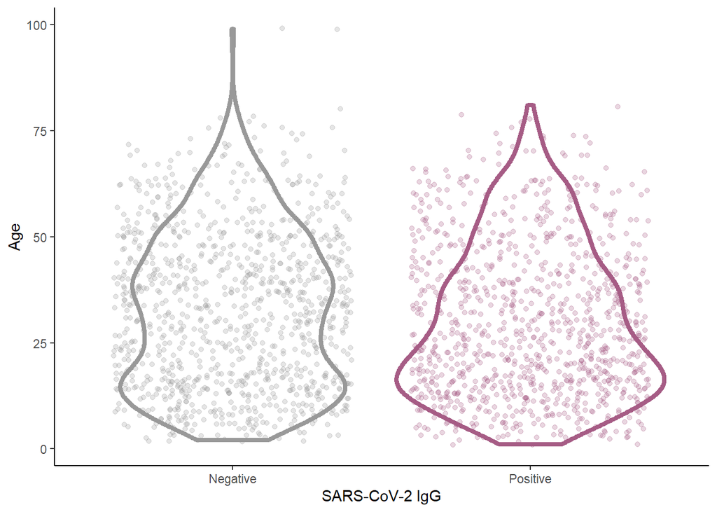

Panel B: : SARS-CoV-2 seroprevalence and 95% confidence interval associated with age, as estimated using a generalized additive model.

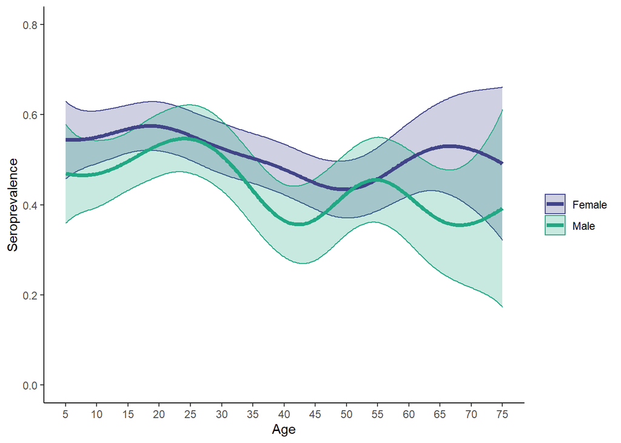

Panel C: Distribution of household size by age among SARS-CoV-2 seronegative and seropositive individuals.

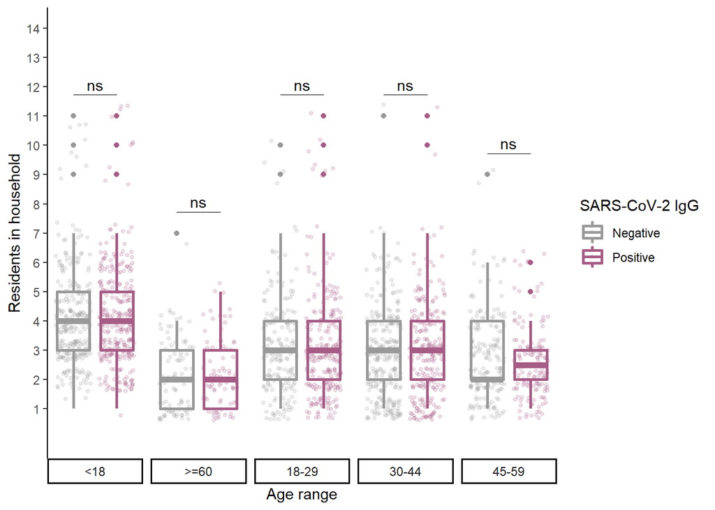

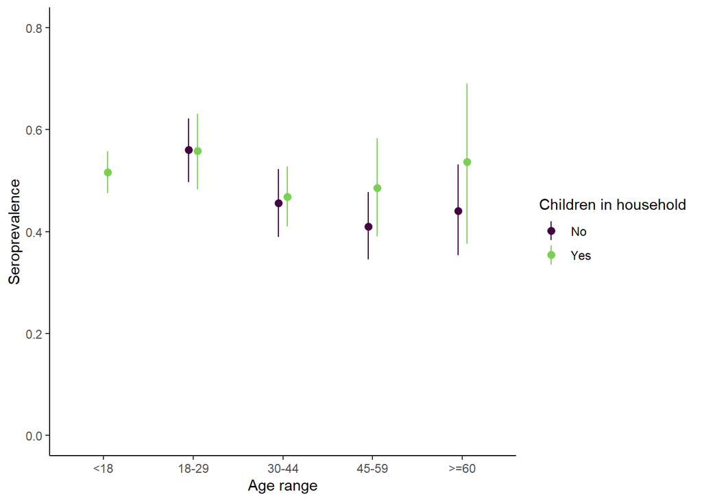

Panel E: Variation in seroprevalence among children by household composition (number of children and number of adults).

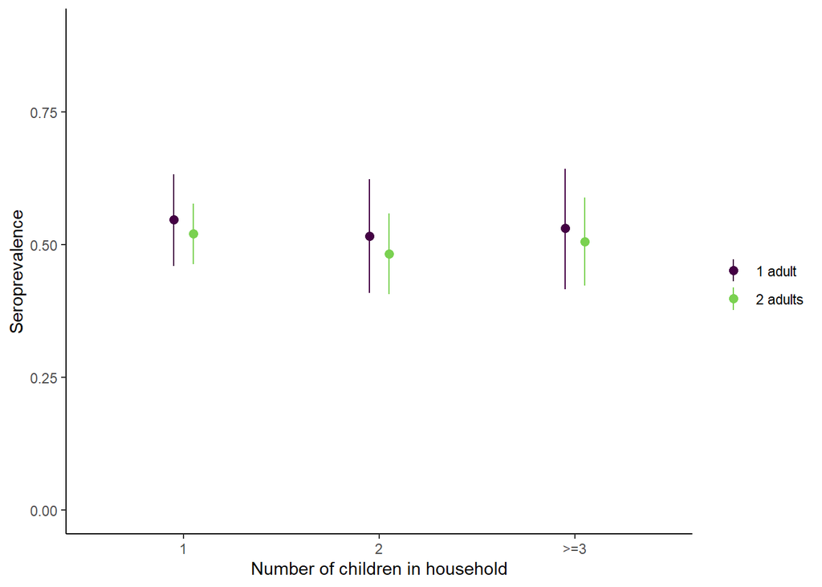

### Figure 3

Panel A: Household income (per capita) by employment status and gender.

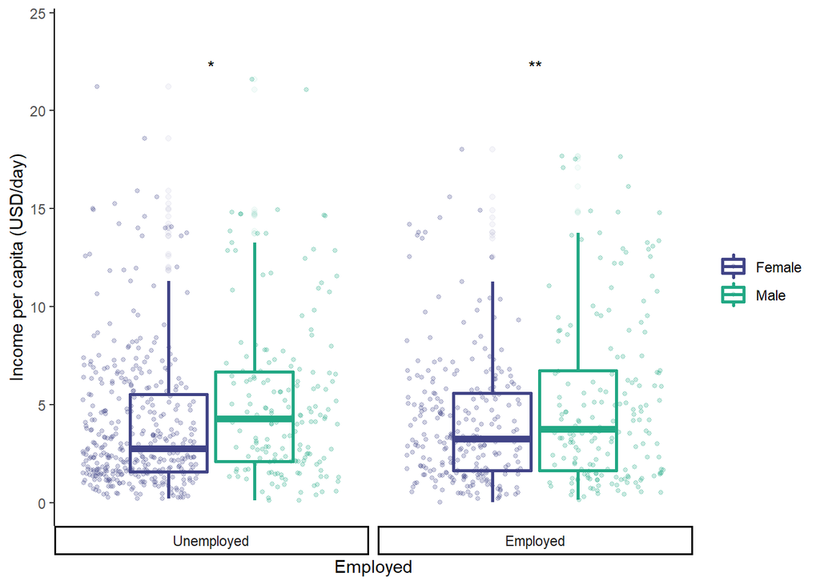

### Multilevel model

1. Are children more susceptible to SARS-CoV-2 after adjusting for household clustering and household size?

|  | OR | LL | UL |
| --- | --- | --- | --- |
| Intercept | 0.8060475 | 0.5733043 | 1.133277 |
| <18 | 1.2280436 | 0.9547085 | 1.579635 |
| >=60 | 1.0321236 | 0.7211104 | 1.477276 |
| 18-29 | 1.4831932 | 1.1403117 | 1.929176 |
| 45-59 | 0.8839592 | 0.6655318 | 1.174074 |
| Income | 0.9833197 | 0.9544422 | 1.013071 |
| Female gender | 1.2720839 | 1.0603339 | 1.526121 |
| Total residents | 0.9939968 | 0.9327700 | 1.059243 |

AIC: 2819.5831887; ICC: 0.0185043

2. Does the size of the household predict seropositivity among adults better than presence of children does?

   |  | OR | LL | UL |
   | --- | --- | --- | --- |
   | Intercept | 0.7607196 | 0.5601488 | 1.033108 |
   | >=60 | 1.0521359 | 0.7289201 | 1.518671 |
   | 18-29 | 1.5112900 | 1.1527561 | 1.981336 |
   | 45-59 | 0.9012310 | 0.6731596 | 1.206575 |
   | Income | 0.9876642 | 0.9588848 | 1.017307 |
   | Female gender | 1.2353070 | 0.9908301 | 1.540106 |
   | Children in household | 1.0697806 | 0.8432232 | 1.357209 |

   |  | OR | LL | UL |
   | --- | --- | --- | --- |
   | Intercept | 0.8493916 | 0.5742699 | 1.256319 |
   | >=60 | 1.0228060 | 0.7106245 | 1.472131 |
   | 18-29 | 1.4947419 | 1.1437164 | 1.953503 |
   | 45-59 | 0.8826252 | 0.6621935 | 1.176434 |
   | Income | 0.9816150 | 0.9507563 | 1.013475 |
   | Female gender | 1.2440926 | 0.9985578 | 1.550002 |
   | Total residents in household | 0.9825268 | 0.9070586 | 1.064274 |

AIC values for these models are 2003.0551645, 2003.1764721 respectively.

ICC values are 0.0315713, 0.0321525 respectively.

### Mediation analysis

Is the effect of presence of children mediated by increased household size?

|  | Estimate | LB | UB | p |
| --- | --- | --- | --- | --- |
| ACME (control) | -0.0072771 | -0.0445834 | 0.0304806 | 0.6996 |
| ACME (treated) | -0.0073475 | -0.0451864 | 0.0304763 | 0.6996 |
| ADE (control) | 0.0175507 | -0.0489814 | 0.0828630 | 0.5828 |
| ADE (treated) | 0.0174804 | -0.0489299 | 0.0824301 | 0.5828 |
| Total Effect | 0.0102033 | -0.0427399 | 0.0635909 | 0.6992 |
| Prop. Mediated (control) | -0.0920891 | -9.0995459 | 8.0919630 | 0.9204 |
| Prop. Mediated (treated) | -0.0924945 | -9.1431832 | 8.0995328 | 0.9204 |
| ACME (average) | -0.0073123 | -0.0449424 | 0.0304881 | 0.6996 |
| ADE (average) | 0.0175156 | -0.0489125 | 0.0826485 | 0.5828 |
| Prop. Mediated (average) | -0.0922918 | -9.1213646 | 8.0957479 | 0.9204 |

### Adjusted seroprevalence estimates

- Adjusted for test sensitivity/sepcificity using multilevel Bayesian logistic model with random intercepts by household.
- Seroprevalence in population of eligible individuals who are included in census is estimated using post-stratification of age- and gender-specific model estimates.

#### Estimates for study participants

| Variable(s) | Subgroup | Seroprevalence (95% CI) |
| --- | --- | --- |
| Adults |  | 50.29 (46.41-55.47) |
| Age | <18 | 55.84 (50.48-62.24) |
| Age | >=60 | 42.32 (34.48-50.53) |
| Age | 18-29 | 54.18 (48.41-60.76) |
| Age | 30-44 | 52.87 (47.42-59.26) |
| Age | 45-59 | 44.84 (38.40-52.12) |
| Age/gender | <18.Female | 58.07 (52.36-64.88) |
| Age/gender | <18.Male | 53.21 (47.20-59.89) |
| Age/gender | >=60.Female | 44.59 (36.38-53.54) |
| Age/gender | >=60.Male | 39.81 (31.85-48.33) |
| Age/gender | 18-29.Female | 56.24 (50.11-63.14) |
| Age/gender | 18-29.Male | 51.35 (44.99-58.26) |
| Age/gender | 30-44.Female | 54.64 (48.76-61.51) |
| Age/gender | 30-44.Male | 49.73 (43.37-56.50) |
| Age/gender | 45-59.Female | 46.61 (39.82-54.29) |
| Age/gender | 45-59.Male | 41.76 (34.78-49.30) |
| Children |  | 55.84 (50.48-62.24) |
| Gender | Female | 53.76 (49.48-59.37) |
| Gender | Male | 49.10 (44.43-54.60) |
| Overall |  | 51.83 (47.98-56.93) |

#### Post-stratified estimates for entire census population

| Variable(s) | Subgroup | Seroprevalence (95% CI) |
| --- | --- | --- |
| Adults |  | 50.25 (46.38-55.37) |
| Age | <18 | 55.82 (50.46-62.23) |
| Age | >=60 | 42.34 (34.49-50.56) |
| Age | 18-29 | 53.98 (48.20-60.53) |
| Age | 30-44 | 52.73 (47.25-59.09) |
| Age | 45-59 | 44.75 (38.28-52.01) |
| Age/gender | <18.Female | 58.07 (52.36-64.88) |
| Age/gender | <18.Male | 53.21 (47.20-59.89) |
| Age/gender | >=60.Female | 44.59 (36.38-53.54) |
| Age/gender | >=60.Male | 39.81 (31.85-48.33) |
| Age/gender | 18-29.Female | 56.24 (50.11-63.14) |
| Age/gender | 18-29.Male | 51.35 (44.99-58.26) |
| Age/gender | 30-44.Female | 54.64 (48.76-61.51) |
| Age/gender | 30-44.Male | 49.73 (43.37-56.50) |
| Age/gender | 45-59.Female | 46.61 (39.82-54.29) |
| Age/gender | 45-59.Male | 41.76 (34.78-49.30) |
| Children |  | 55.82 (50.46-62.23) |
| Gender | Female | 53.69 (49.41-59.29) |
| Gender | Male | 49.09 (44.43-54.58) |
| Overall |  | 51.70 (47.87-56.79) |